# Building AI Models for Pregnancy Prediction

Damola Mabogunje

2023-03-08

```r
# Hardcode the US repo for CRAN
r <-getOption("repos");
r["CRAN"] <- "http://cran.us.r-project.org";
options(repos = r);
rm(r);
```

## Introduction

This R Markdown document replicates the work done in chapters 6 & 7 of the Data Smart book by John W. Foreman which treats the techniques of Regression and Ensemble Modelling using Excel.

Here, we’re going to be using R to achieve the same goal by calling on thev powers of the glm (“general linear modelling”) function and the random forest library as well as the ROCR library for analyzing the performance of our models.

But first, we must import our libraries and prepare our data!

```r
install.packages("randomForest", dependencies = TRUE);
install.packages("ROCR", dependencies = TRUE);
library(randomForest);
library(ROCR);
```

Libraries imported. Now we can prep the data.

```r
# Read in the Pregnancy Data
PregnancyData <- read.csv("data/Pregnancy.csv");
PregnancyData.Test <- read.csv("data/Pregnancy_Test.csv");

str(PregnancyData); # Data check
```

```
## 'data.frame':    1000 obs. of  18 variables:
##  $ Implied.Gender        : chr  "M" "M" "M" "U" ...
##  $ Home.Apt..PO.Box      : chr  "A" "H" "H" "H" ...
##  $ Pregnancy.Test        : int  1 1 1 0 0 0 0 0 0 0 ...
##  $ Birth.Control         : int  0 0 0 0 0 0 1 0 0 0 ...
##  $ Feminine.Hygiene      : int  0 0 0 0 0 0 0 0 0 0 ...
##  $ Folic.Acid            : int  0 0 0 0 0 0 1 0 0 0 ...
##  $ Prenatal.Vitamins     : int  1 1 0 0 0 1 1 0 0 1 ...
##  $ Prenatal.Yoga         : int  0 0 0 0 1 0 0 0 0 0 ...
##  $ Body.Pillow           : int  0 0 0 0 0 0 0 0 0 0 ...
##  $ Ginger.Ale            : int  0 0 0 1 0 0 0 0 1 0 ...
##  $ Sea.Bands             : int  0 0 1 0 0 0 0 0 0 0 ...
##  $ Stopped.buying.ciggies: int  0 0 0 0 0 1 0 0 0 0 ...
##  $ Cigarettes            : int  0 0 0 0 0 0 0 0 0 0 ...
##  $ Smoking.Cessation     : int  0 0 0 0 0 0 0 0 0 0 ...
##  $ Stopped.buying.wine   : int  0 0 0 0 1 0 0 0 0 0 ...
##  $ Wine                  : int  0 0 0 0 0 0 0 0 0 0 ...
##  $ Maternity.Clothes     : int  0 0 0 0 0 0 0 1 0 1 ...
##  $ PREGNANT              : int  1 1 1 1 1 1 1 1 1 1 ...
```

```r
# Correctly Interpret Categorical fields as such
PregnancyData$Implied.Gender <- factor(PregnancyData$Implied.Gender);
PregnancyData$Home.Apt..PO.Box <- factor(PregnancyData$Home.Apt..PO.Box);
PregnancyData$PREGNANT <- factor(PregnancyData$PREGNANT);
PregnancyData.Test$Implied.Gender <- factor(PregnancyData.Test$Implied.Gender);
PregnancyData.Test$Home.Apt..PO.Box <- factor(PregnancyData.Test$Home.Apt..PO.Box);
PregnancyData.Test$PREGNANT <- factor(PregnancyData.Test$PREGNANT);

str(PregnancyData.Test); # Data check
```

```
## 'data.frame':    1000 obs. of  18 variables:
##  $ Implied.Gender        : Factor w/ 3 levels "F","M","U": 3 3 2 2 2 2 1 1 1 1 ...
##  $ Home.Apt..PO.Box      : Factor w/ 3 levels "A","H","P": 1 2 2 2 1 2 2 3 3 2 ...
##  $ Pregnancy.Test        : int  0 0 0 0 0 0 0 0 0 0 ...
##  $ Birth.Control         : int  0 0 0 0 0 0 0 0 0 0 ...
##  $ Feminine.Hygiene      : int  0 0 0 0 0 0 0 0 0 0 ...
##  $ Folic.Acid            : int  0 0 0 0 0 1 0 0 0 0 ...
##  $ Prenatal.Vitamins     : int  0 0 0 0 0 0 0 0 0 0 ...
##  $ Prenatal.Yoga         : int  0 0 0 0 0 0 0 0 0 0 ...
##  $ Body.Pillow           : int  0 0 0 0 0 0 0 0 0 0 ...
##  $ Ginger.Ale            : int  0 0 0 0 0 1 0 0 0 0 ...
##  $ Sea.Bands             : int  1 0 0 0 0 0 0 0 0 0 ...
##  $ Stopped.buying.ciggies: int  0 0 1 0 0 0 0 0 0 1 ...
##  $ Cigarettes            : int  0 0 0 0 0 0 0 0 0 1 ...
##  $ Smoking.Cessation     : int  0 0 0 0 0 0 0 0 0 0 ...
##  $ Stopped.buying.wine   : int  1 0 0 1 0 1 1 0 0 0 ...
##  $ Wine                  : int  1 0 0 0 0 0 0 0 0 0 ...
##  $ Maternity.Clothes     : int  0 0 0 0 0 0 1 0 0 1 ...
##  $ PREGNANT              : Factor w/ 2 levels "0","1": 2 2 2 2 2 2 2 2 2 2 ...
```

## Modelling

Now we have our data. Let us create our models

```r
# General Linear Model (Logistic Regression)
Pregnancy.lm <- glm(PREGNANT ~ ., data = PregnancyData, family = binomial("logit"));

# Ensemble / Random Forest Model
Pregnancy.rf <- randomForest(PREGNANT ~ ., data = PregnancyData, importance = TRUE);

summary(Pregnancy.lm); # Check Model
```

```
##
## Call:
## glm(formula = PREGNANT ~ ., family = binomial("logit"), data = PregnancyData)
##
## Deviance Residuals:
##     Min       1Q   Median       3Q      Max
## -3.2012  -0.5566  -0.0246   0.5127   2.8658
##
## Coefficients:
##                         Estimate Std. Error z value Pr(>|z|)
## (Intercept)            -0.343597   0.180755  -1.901 0.057315 .
## Implied.GenderM        -0.453880   0.197566  -2.297 0.021599 *
## Implied.GenderU         0.141939   0.307588   0.461 0.644469
## Home.Apt..PO.BoxH      -0.172927   0.194591  -0.889 0.374180
## Home.Apt..PO.BoxP      -0.002813   0.336432  -0.008 0.993329
## Pregnancy.Test          2.370554   0.521781   4.543 5.54e-06 ***
## Birth.Control          -2.300272   0.365270  -6.297 3.03e-10 ***
## Feminine.Hygiene       -2.028558   0.342398  -5.925 3.13e-09 ***
## Folic.Acid              4.077666   0.761888   5.352 8.70e-08 ***
## Prenatal.Vitamins       2.479469   0.369063   6.718 1.84e-11 ***
## Prenatal.Yoga           2.922974   1.146990   2.548 0.010822 *
## Body.Pillow             1.261037   0.860617   1.465 0.142847
## Ginger.Ale              1.938502   0.426733   4.543 5.55e-06 ***
## Sea.Bands               1.107530   0.673435   1.645 0.100053
## Stopped.buying.ciggies  1.302222   0.342347   3.804 0.000142 ***
## Cigarettes             -1.443022   0.370120  -3.899 9.67e-05 ***
## Smoking.Cessation       1.790779   0.512610   3.493 0.000477 ***
## Stopped.buying.wine     1.383888   0.305883   4.524 6.06e-06 ***
## Wine                   -1.565539   0.348910  -4.487 7.23e-06 ***
## Maternity.Clothes       2.078202   0.329432   6.308 2.82e-10 ***
## ---
## Signif. codes:  0 '***' 0.001 '**' 0.01 '*' 0.05 '.' 0.1 ' ' 1
##
## (Dispersion parameter for binomial family taken to be 1)
##
##     Null deviance: 1386.29  on 999  degrees of freedom
## Residual deviance:  744.11  on 980  degrees of freedom
## AIC: 784.11
##
## Number of Fisher Scoring iterations: 7
```

## Predicting with our Models

Now we use our models to predict the PREGNANT field using all other fields.

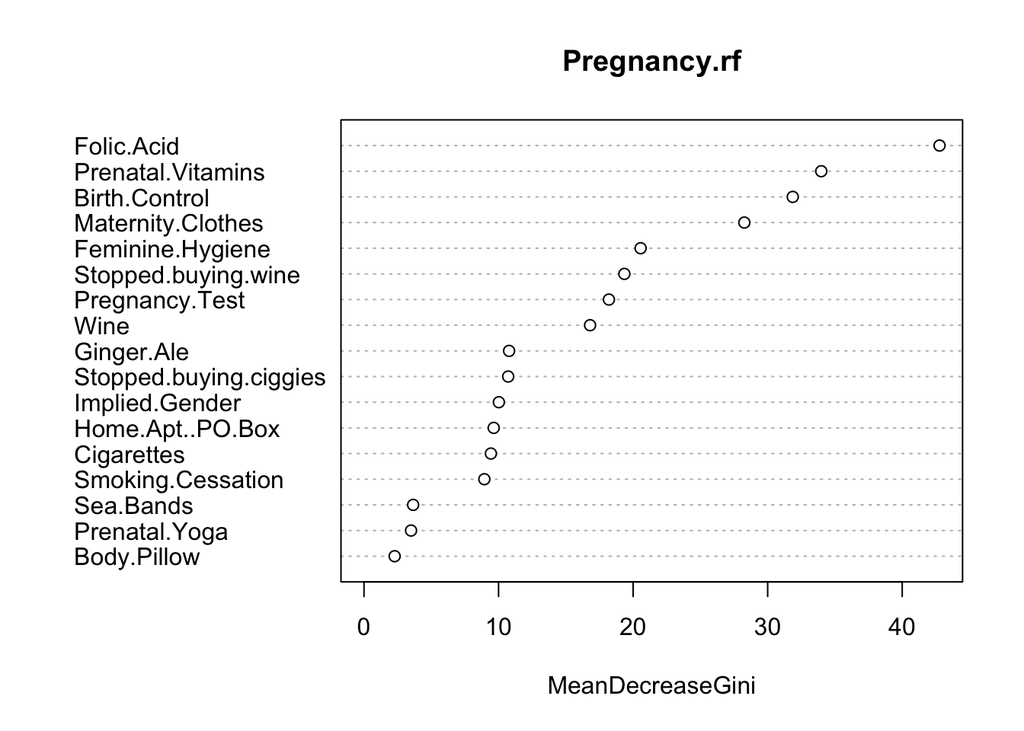

```r
## Predictions on Test Data using Random Forest Model
PregnancyData.Test.rf.Preds <- predict(Pregnancy.rf, PregnancyData.Test, type = "prob");

## Predictions on Test Data using Linear Regression Model
PregnancyData.Test.lm.Preds <- predict(Pregnancy.lm, PregnancyData.Test, type = "response")

# Plot Predictive Strength of Variables Used to Predict Pregnancy
varImpPlot(Pregnancy.rf, type = 2);
```

## Measuring the Performance of Our Models

Now we want to look at how well our models trained on the *PregnancyData*, performed on predicting the Pregnancy outcomes of the *PregnancyData.Test*.

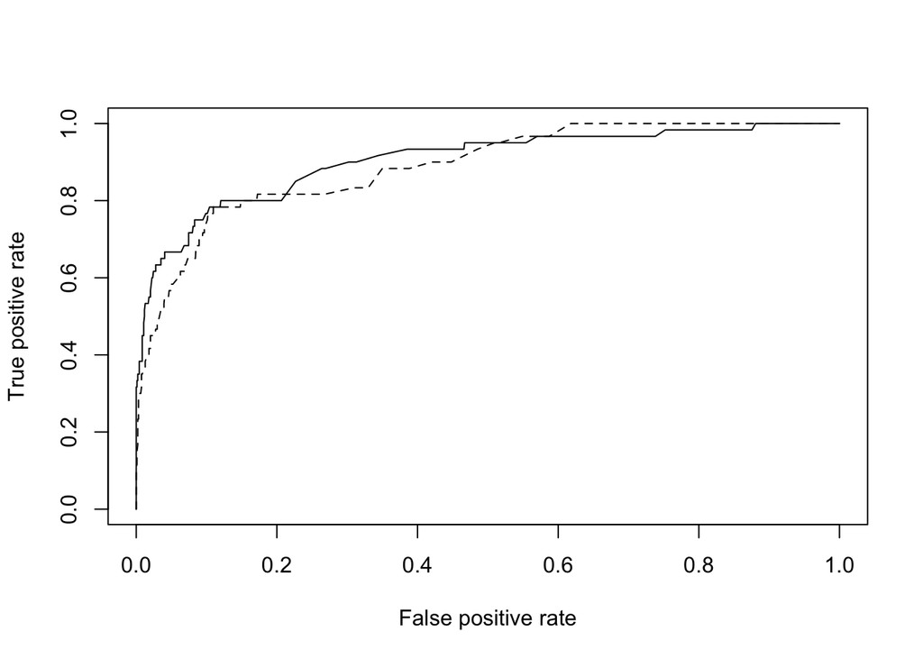

```r
# Linear Regression Model's Predictions
pred.lm <- prediction(PregnancyData.Test.lm.Preds, PregnancyData.Test$PREGNANT);

# Random Forest's Predictions
pred.rf <- prediction(PregnancyData.Test.rf.Preds[,2], PregnancyData.Test$PREGNANT);

# Measuring Performance via True Positive Rate (tpr) and False Positive Rate (fpr);
perf.lm <- performance(pred.lm, "tpr", "fpr");
perf.rf <- performance(pred.rf, "tpr", "fpr");

## Plotting Performance
plot(perf.lm, xlim=c(0,1), ylim=c(0,1));
plot(perf.rf, xlim=c(0,1), ylim=c(0,1), lty=2, add=TRUE)
```

## Conclusion

In Conclusion, we can see that both models provide similar levels of efficacy on the same training and test data, with the logistic regression performing a little bit better in the beginning and mid sections.